# Statistisk inferensteori Frekventistiska metoder (H & B, Kapitel 3)

7 november 2016

## Frekventistisk statistik

## Skattning och skattare

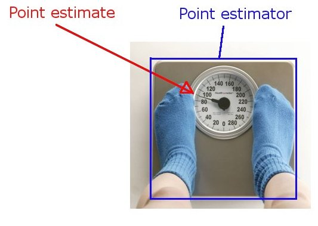

## Skattning och skattare

**Definition:** (Skattning/Skattare, H & B, def. 3.1) Antag att vi modellerar data \(x\) som en realisering av en stokastisk variabel \(X\sim P_{\theta_0}\). Med *skattning* syftar vi på ett numerisk värde \(t=\hat{\theta}(x)\), med *skattare* syfter vi på funktionen \(\hat{\theta}:\mathcal{T}\rightarrow\Theta\) alternativt den stokastiska variabeln \(T=\hat{\theta}(X)\), \(X\sim P_{\theta}\).

## Riktighet och precision (accuracy/trueness and precision)

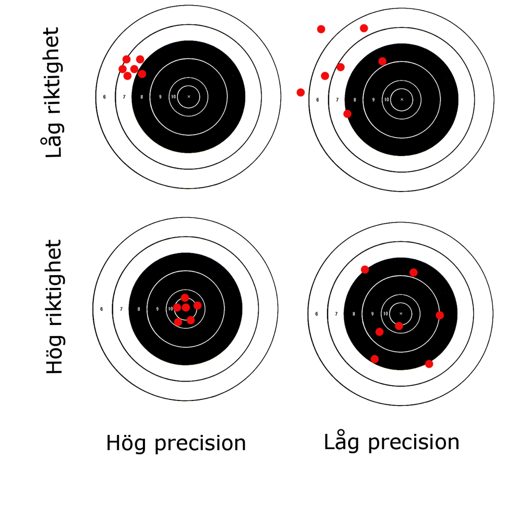

## Egenskaper hos skattare

**Definition:** (Medelkvadratfel, H & B (3.4)) En skattare \(\hat{\theta}(\cdot)\):s medelkvadratfel är \[MSE(\theta)=E_\theta (\hat{\theta}(X)-\theta)^2=Var_\theta(\hat{\theta}(X))+(E_\theta[\hat{\theta}(X)-\theta])^2.\]

**Definition:** (H & B, Def. 3.2) En skattare \(\hat{\theta}(\cdot)\):s bias (väntevärdesfel, systematiska fel) är \[E_\theta(\hat{\theta}(X)-\theta).\] Om \(E_\theta(\hat{\theta}(X)-\theta)=0\) för alla \(\theta\in\Theta\) säges \(\hat{\theta}(\cdot)\) vara väntevärdesriktig (unbiased).

## Två problem:

Vi vill beskriva osäkerheten i en skattning \(\hat{\theta}\) med hjälp av fördelningen hos \(\hat{\theta}(X)\), \(X\sim P_{\theta_0}\), men…

- denna beror på okända \(\theta_0\)
- även om vi vet \(\theta_0\), är det endast möjligt att bestämma fördelningen analytiskt i enkla fall.

## Bootstrap

## Monte Carlo integrering

Vi kan approximera ett väntevärde \(m=E(g(X))\), \(X\sim P\), med godtycklig noggrannhet genom att

- Simulera \(x_1,\ldots, x_N\) från \(P\).
- Approximera \(m\) med \(\hat{m}=N^{-1}\sum_{i=1}^N g(x_i)\).

## Monte Carlo integrering

```r
x <- runif(100000)
mean(sin(1 / x))
```

```
## [1] 0.5029087
```

```r
x <- runif(100000)
mean(sin(1 / x))
```

```
## [1] 0.5073855
```

## Bootstrap (Plug-in + Monte Carlo)

Vi vill skatta egenskap hos \(P_{\theta_0}\), t.ex. \[\phi_0=Var_{\theta_0}(\hat{\theta}(X))=h(\theta_0),\] men saknar såväl \(\theta_0\) som användbart uttryck för \(h(\cdot)\).

## Bootstrap (Plug-in + Monte Carlo)

- **Plug-in:** Skatta \(P_{\theta_0}\) med \(P_{\hat{\theta}}\) (\(h(\theta_0)\) med \(h(\hat{\theta})\)).
- **Monte Carlo:** Approximera \(h(\hat{\theta})\) genom att simulera \(N\) nya stickprov \(x_1^*,\ldots, x_N^*\), \(x_i^*\in\mathcal{T}\), från \(P_{\hat{\theta}}\) och använd dessa för att empiriskt approximera storheten av intresse.

## Bootstrap (Plug-in + Monte Carlo)

Med \(\phi=h(\theta_0)=Var_{\theta_0}(\hat{\theta}(X)),\) använder vi \[ \hat{\phi}=\frac{1}{N-1}\sum_{i=1}^N(\theta^*_i-\bar{\theta^*})^2\approx h(\hat{\theta}). \] där \(\theta^*_i=\hat{\theta}(x_i^*)\).

## Bootstrap, livslängder

Vad är fördelningen för \(\hat{\theta}(X), X\sim P_\hat{\theta}\)?

```r
# Dra N stickprov av storlek 28 från anpassad Exponentialfördelning
# Bestäm ML-skattning för varje stickprov och spara i theta.boot
theta.hat <- 1 / mean(ac)
N <- 10000
theta.boot <- numeric(10000)
for (i in 1:N){
    x <- rexp(28, rate = theta.hat)
    theta.boot[i] <- 1 / mean(x)
}
```

## Bootstrap, livslängder

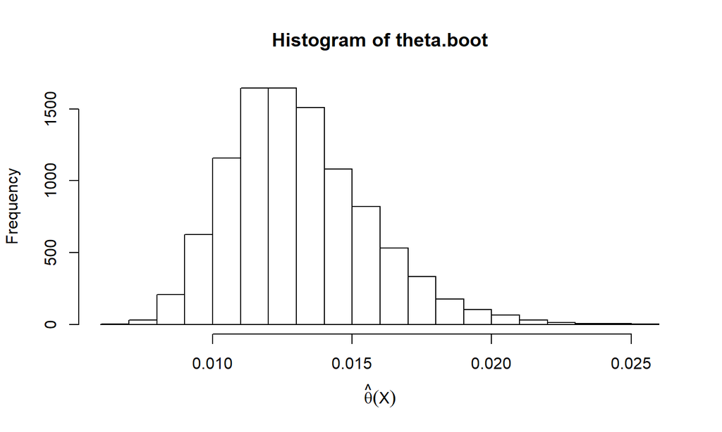

```r
hist(theta.boot, xlab = expression(hat(theta)(X)))
```

## Bootstrap, livslängder

Bias

```r
bias.theta <- mean(theta.boot)-theta.hat
bias.theta
```

```
## [1] 0.0004516609
```

en numerisk approximation av

```r
theta.hat / 27
```

```
## [1] 0.0004683997
```

## Bootstrap, livslängder

Standardfel

```r
se.theta <- sd(theta.boot)
se.theta
```

```
## [1] 0.002520815
```

en numerisk approximation av

```r
28 * theta.hat / (27 * sqrt(26))
```

```
## [1] 0.002572101
```

## Bootstrap, livslängder

Låt \(\phi_0=P_{\theta_0}(X_i>100)=\exp(-\theta_0 100)\).

Plug-in skattning är \(\hat{\phi}=P_{\hat{\theta}}(X_i>100)=\exp(-\hat{\theta} 100)\) med numeriskt standardfel

```r
phi.boot <- exp(-theta.boot * 100)
se.phi <- sd(phi.boot)
se.phi
```

```
## [1] 0.06529069
```

## Icke-parametrisk Bootstrap

Antag \(x_1,\ldots, x_n\) är oberoende realiseringar av \(X\) med fördelningsfunktion \(F_0\).

- Vi skattar \(F_0\) med empiriska fördelningsfunktionen, \[ \hat{F}(\cdot)=\frac{1}{n}\sum_{i=1}^n \mathbf{1}\{x_i\leq \cdot\} \]
- Ett stickprov från \(\hat{F}\) fås genom dragning med återläggning från \(\{x_1,\ldots,x_n\}\).
- Upprepa…

## Icke-parametrisk Bootstrap, Livslängder

```r
# Dra N stickprov av storlek 28 från empirisk fördelning
# Bestäm skattning för varje stickprov och approximera standardfel
N <- 10000
theta.np.boot <- numeric(10000)
for (i in 1:N){
    x <- sample(ac, size = 28, replace = TRUE)
    theta.np.boot[i] <- 1 / mean(x)
}
se.np.theta <- sd(theta.np.boot)
se.np.theta
```

```
## [1] 0.002089577
```

## Asymptotik

## Konvergens i sannolikhet

**Definition:** (Konvergens i sannolikhet, H & B A.4.1) En sekvens stokastiska variabler \(T_n\), \(n=1,\ldots\) konvergerar i sannolikhet mot \(T\) om \(P(|T_n-T|>\epsilon)\rightarrow 0\) då \(n\rightarrow \infty\) för alla \(\epsilon>0\).

**Definition:** (Konsistens, H & B Def. 3.4) En (sekvens) skattare \(T_n=\hat{\theta}(X_{1:n})\), \(n=1, \dots\), säges vara en konsistent (sekvens) skattare av \(\theta\) om den konvergerar mot \(\theta\) i sannolikhet då \(n\rightarrow\infty\) för alla \(\theta\). Den är vidare konsistent i medelkvadrat om \(MSE(\theta)\rightarrow 0\) för alla \(\theta\).

## Stora talens lag

**Sats:** (Stora talens lag, H & B, A.4.3) Låt \(X_1, \ldots, X_n\) vara oberoende likafördelade med \(E(X_i)=\mu\).

Då konvergerar \(T_n=n^{-1}\sum_{i=1}^n X_i\) mot \(\mu\) i sannolikhet då \(n\rightarrow \infty\).

**Continuous mapping theorem:** (H & B, A.4.2) Om \(T_n\) konvergerar i sannolikhet mot \(T\) och \(g\) är kontinuerlig så konvergerar \(g(T_n)\) i sannolikhet mot \(g(T)\).

## Konvergens i fördelning

**Definition:** (Konvergens i fördelning, H & B A.4.1) En sekvens stokastiska variabler \(T_n\), \(n=1,\ldots\) konvergerar i fördelning mot \(T\) om \(F_n(t)=P(T_n\leq t)\) konvergerar mot \(F(t)=P(T\leq t)\) för alla \(t\) där \(F\) är kontinuerlig.

## Centrala gränsvärdessatsen och deltametoden

**Sats:** (Centrala gränsvärdessatsen, H & B A.4.4) Låt \(X_1, \ldots, X_n\) vara oberoende likafördelade med \(E(X_i)=\mu\) och \(Var(X_i)=\sigma^2\).

Då konvergerar \(T_n=\sqrt{n}(n^{-1}\sum_{i=1}^n X_i-\mu)\) mot \(T\sim N(0,\sigma^2)\) i fördelning då \(n\rightarrow \infty\).

**Sats:** (Deltametoden, H & B A.4.5) Antag att \(\sqrt{n}(T_n-\theta)\) konvergerar i fördelning mot \(N(0,\sigma^2)\) och låt \(g\) vara en funktion sådan att \(g'(\theta)\neq 0\).

Då konvergerar \(\sqrt{n}(g(T_n)-g(\theta))\) i fördelning mot \(N(0,\sigma^2g'(\theta)^2)\).

## Standardfel och konfidensintervall

## Standardfel

H & B använder en generisk definition av begreppet standardfel:

**Definition:** (H & B, Def. 3.6) En skattning \(\hat{\theta}\):s standardfel är \(se(\hat{\theta})=\sqrt{v_n}\), där \(V_n\) är en konsistent skattare av \(Var(T_n)\) i meningen att \(V_n/Var(T_n)\rightarrow 1\) i sannolikhet då \(n\rightarrow\infty\).

## Konfidensintervall

**Definition:** (H & B, Def. 3.6)

Låt \(T_l=h_l(X)<h_u(X)=T_u\) vara två stickprovsvariabler. Om \(P_\theta(T_l\leq\theta\leq T_u)=\gamma\) för alla \(\theta\) och \(x\) är en realisering av \(X\sim P_{\theta_0}\) säges \((t_l,t_u)=(h_l(x),h_u(x))\) vara ett konfidensintervall för \(\theta_0\) med konfidensgrad \(\gamma\).

Hur bestämmer vi \(h_l\) och \(h_u\) för ett givet \(\gamma\)?

## Konfidensintervall

Ett konfidensintervall är en *intervallskattning*. En *punktskattning* är då

- en punkt (d.v.s. \(\hat{\theta}\)) som skattar någonting (t.ex. punkten \(\theta_0\))?
- någonting (t.ex. punkten \(\hat{\theta}\)) som skattar en punkt (d.v.s. \(\theta_0\))?

## Pivåvariabel

**Definition:** (H & B, Def. 3.7) En pivåvariabel är en funktion \(g(x, \theta)\) sådan att fördelningen för \(g(X,\theta)\) inte beror på \(\theta\) då \(X\sim P_\theta\).

En funktion \(g_n(x_{1:n}, \theta)\) sådan att gränsfördelningen (då \(n\rightarrow\infty\)) för \(g_n(X_{1:n},\theta)\) inte beror på \(\theta\) är en approximativ/asymptotisk pivåvariabel.

## Konfidensintervall, livslängder

Ett 95%-igt intervall ges av

```r
C.1 <- qgamma(c(0.025, 0.975), 28, 1) / sum(ac)
C.1
```

```
## [1] 0.008403702 0.017743262
```

## Wald-intervall

Låt \(T_n=\hat{\theta}(X_1,\ldots,X_n)\) vara konsistent och asymptotiskt normalfördelad så att \[ \frac{T_n-\theta}{\sqrt{Var(T_n)}}\rightarrow N(0,1), \] i fördelning då \(n\rightarrow\infty\), \(X\sim P_\theta^n\).

Då ges ett Wald-intervall med approximativ konfidensgrad \(\gamma\) av \[ \hat{\theta}\pm z_{(1+\gamma)/2}\cdot se(\hat{\theta}). \]

## Wald-intervall, livslängder

```r
se <- theta.hat / sqrt(28)
C.2 <- theta.hat + se * qnorm(c(0.025, 0.975))
C.2
```

```
## [1] 0.007962441 0.017331145
```

## Transformerat Wald-intervall, livslängder

```r
se <- 1 / sqrt(28)
C.3 <- exp(log(theta.hat) + se * qnorm(c(0.025, 0.975)))
C.3
```

```
## [1] 0.008732095 0.018316496
```

## Bootstrap-intervall, livslängder

```r
delta <- theta.boot - theta.hat
C.4 <- theta.hat - quantile(delta, c(0.975, 0.025), names = FALSE)
C.4
```

```
## [1] 0.00642704 0.01623925
```

```r
C.5 <- quantile(theta.boot, c(0.025, 0.975), names = FALSE)
C.5
```

```
## [1] 0.009054338 0.018866546
```

## Alla intervall

```r
rbind(C.1, C.2, C.3, C.4, C.5)
```

```
##            [,1]       [,2]
## C.1 0.008403702 0.01774326
## C.2 0.007962441 0.01733114
## C.3 0.008732095 0.01831650
## C.4 0.006427040 0.01623925
## C.5 0.009054338 0.01886655
```

## Hypotestester

## Fisher (1890-1962)

[figure not shown]

## Enkel och sammansatt hypotes, P-värde

**Definition:** Givet en statistisk modell \(\mathcal{P}=\{P_\theta, \theta\in\Theta\}\) definieras en statistisk hypotes \(H\) som en delmängd, \(\Theta_0\), av parameterrummet. Om hypotesen innehåller en punkt i parameterrummet, \(\Theta_0=\{\theta_0\}\), säges den vara enkel, annars sammansatt.

**Definition:** En test-variabel \(T\) är en stickprovsvariabel som mäter avvikelsen från en hypotes \(H\). Det (ensidiga) \(P\)-värdet definieras som \(P_{\theta_0}(T\geq t)\) för en enkel hypotes och \(\sup_{\{\theta\in\Theta_0\}} P_{\theta}(T\geq t)\) för en sammansatt.

## Kvalitetskontroll

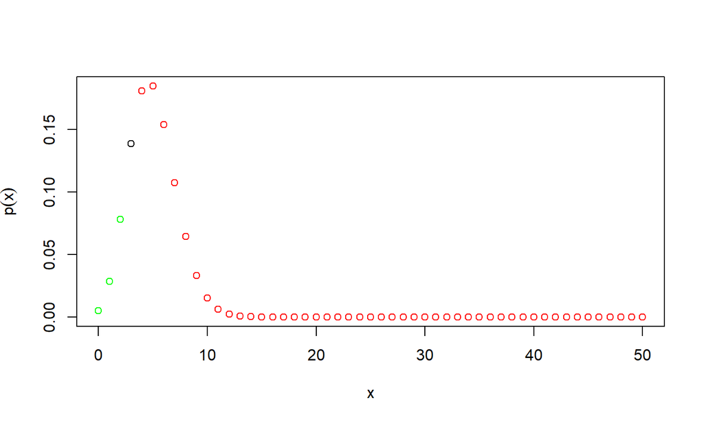

## Kvalitetskontroll

```r
p <- 1 - pbinom(2, prob = 0.1, size = 50)
p
```

```
## [1] 0.8882712
```

## Livslängder

Histogram över simulerade \(T = |1/\bar{X}-0.01|\) då \(\theta=0.01\).

```r
T <- abs(1 / rgamma(100000, 28, 28 * 0.01) - 0.01)
```

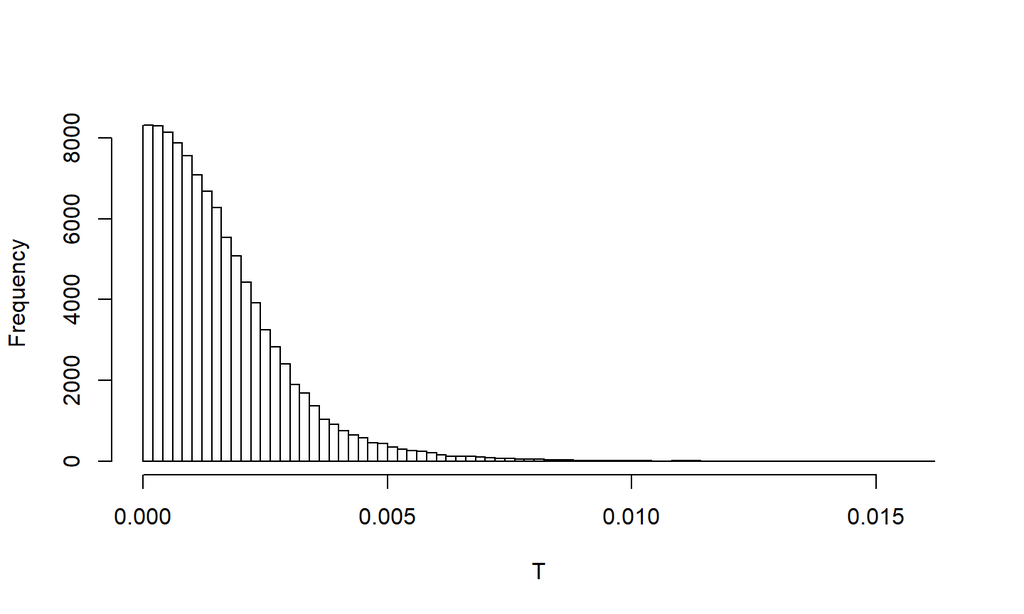

## Livslängder

```r
t <- abs(theta.hat - 0.01)
p <- mean(T > t)
p
```

```
## [1] 0.16797
```

`t` är observerat värde medan `T` är vektor simulerade värden under \(H_0\).

[figure not shown]

## Hypotestest

**Definition:** Ett hypotestest är en regel som avgör ifall observerade data \(x\) är förenliga med en given hypotes \(H_0\), noll-hypotesen.

Om \(x\in R\subset \mathcal{T}\), där \(R\) är testets förkastningsområde, förkastas noll-hypotesen till förmån för en alternativ hypotes \(H_A\).

Testet sägs ha signifikansnivå \(\alpha\) om \(\sup_{\{\theta\in\Theta_0\}} P_{\theta}(X\in R)\leq\alpha\).

Testets styrkefunktion är \(\beta(\theta)=P_{\theta}(X\in R)\).

## Tester och p-värden

**Hjälpsats:** Om \(X\) har kontinuerlig fördelningsfunktion \(F\) så är \(F(X)\) (och då även \(1-F(X)\)) likformigt fördelade på \([0,1]\).

## Livslängder

```r
r <- quantile(T, 0.95)
r
```

```
##         95%
## 0.004101075
```

`T` är simulerade värden under \(H_0\), vi förkastar om observerat är större än `r`

```r
t > r
```

```
##   95%
## FALSE
```

## Livslängder

Ekvivalent med att

```r
p < 0.05
```

```
## [1] FALSE
```

## Livslängder, styrkefunktion

\(\beta(\theta)=P_\theta(X\in R)=P_\theta(T >\) 0.0041011 \()\).

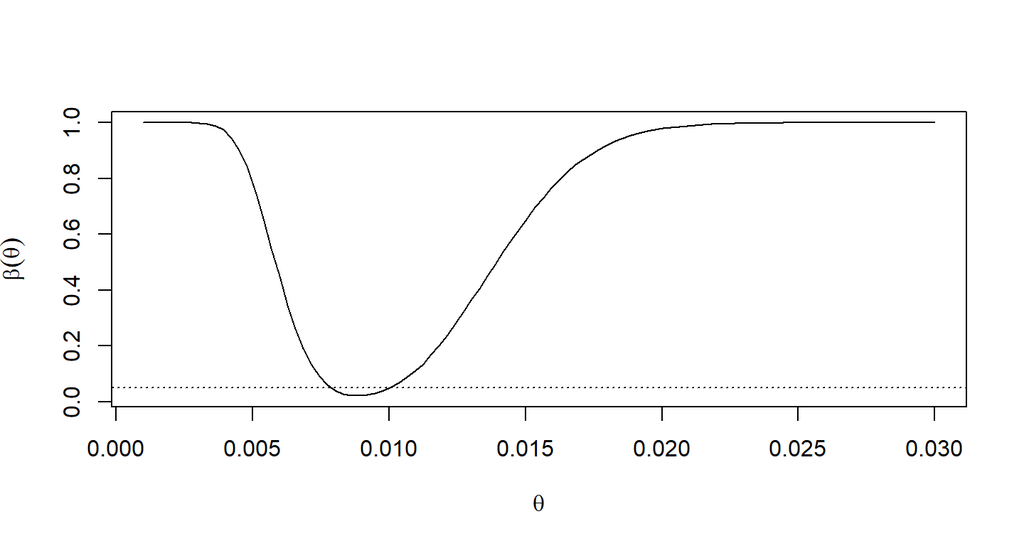

## Kvalitetskontroll, styrka

Förkasta då \(x>r\) så att \(P_{0.1}(X> r)=1-P_{0.1}(X\leq r)\leq 0.05\)

```r
r <- qbinom(0.95, size = 50, prob = 0.1)
1 - pbinom(r, size = 50, prob = 0.1)
```

```
## [1] 0.02453794
```

```r
1 - pbinom(r - 1, size = 50, prob = 0.1)
```

```
## [1] 0.05786721
```

```r
r
```

```
## [1] 9
```

## Kvalitetskontroll, styrka

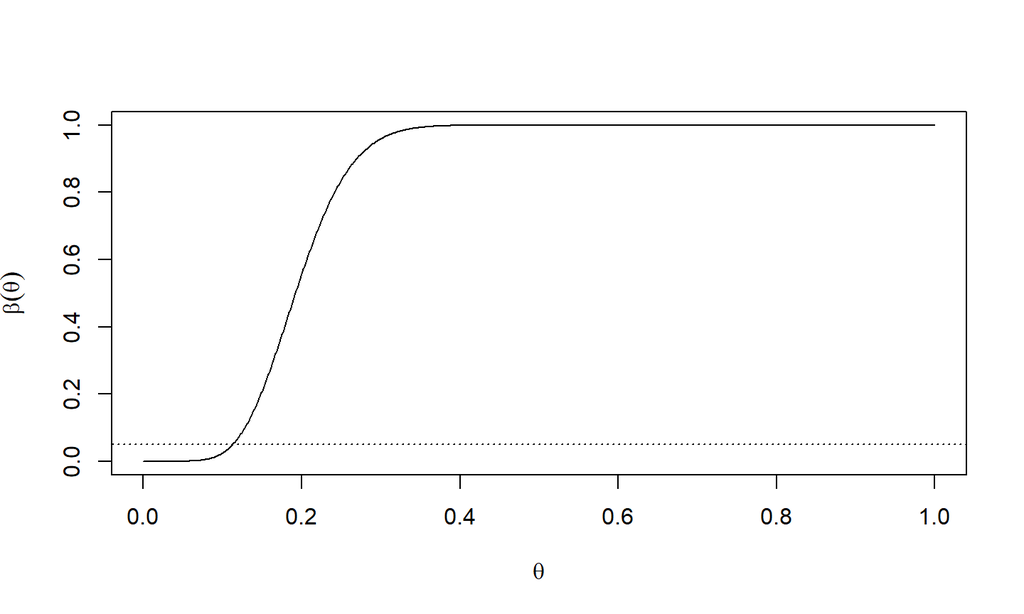